# Introduction to Shiny, Session 2

## Pointer clicks on plots

Shiny also makes it easy to interact with plots. This cool feature can really enhance the user’s ability to get information quickly from a simple looking app.

The *plotOutput* function has a ‘click’ argument, and the string used (e.g. ‘plot_click’) becomes the name of an element in the input object that can be accessed in the server function. For example, *plotOutput(“plot”, click = “plot_click”)* will result in ‘input$plot_click’ being available in server.

In this case, ‘input$plot_click’ would be a list that contains the coordinates of the click. These coordinates can then be used in another Shiny function, *nearPoints*, which takes the clikc input object and the dataframe used for the plot, and returns the rows from the closest point (or points).

## Pointer clicks on plots

Here we show a table with the row of the clicked point in the server using the *nearPoints* function. The ‘threshold’ argument sets the distance (in y value space) from the point that is detected, and we also only return the closest point by setting ‘maxpoints’ to be one.

```r
ui <- page_fluid(
  plotOutput("volcano_plot", click = "volcano_click"), #<<

  tableOutput("selected_point_table"),
)

server <- function(input, output){
  volcano_plot_reac <- reactive({
        ggplot(de_table, aes(x = log2FoldChange, y = negLog10_pval)) +
          geom_point() +
          theme_bw()
    })

  output$volcano_plot = renderPlot(volcano_plot_reac())

  output$selected_point_table <- renderTable({
    nearPoints(de_table, input$volcano_click, threshold = 20, maxpoints = 1) #<<
  })
}
```

## Pointer clicks on plots

[figure not shown]

```r
shinyApp(ui, server)
```

## Pointer brush on plots

A brush can be used in a similar way as the click. The ‘brush’ argument is set in *plotOutput* in the UI and we can then track the points that are in the selected area by rendering a table with the dataframe output from the *brushedPoints* function.

```r
ui <- page_fluid(
  plotOutput("volcano_plot", brush = "volcano_brush"), #<<

  tableOutput("selected_brush_table")
)

server <- function(input, output){

  volcano_plot_reac <- reactive({
        ggplot(de_table, aes(x = log2FoldChange, y = negLog10_pval)) +
          geom_point() +
          theme_bw()
    })

  output$volcano_plot = renderPlot(volcano_plot_reac())

  output$selected_brush_table <- renderTable({
    brushedPoints(de_table, input$volcano_brush) #<<
  })
}
```

## Pointer brush on plots

[figure not shown]

```r
shinyApp(ui, server)
```

## Interactive plots with Plotly

```r
library(plotly)
ui <- page_fluid(
  plotlyOutput("volcano_plotly"), #<<
)

server <- function(input, output){
  volcano_plot_reac <- reactive({
        ggplot(de_table, aes(x = log2FoldChange, y = negLog10_pval, text = Symbol)) +
          geom_point() +
          theme_bw()
    })

  output$volcano_plotly = renderPlotly(ggplotly(volcano_plot_reac())) #<<

}
```

## Interactive plots with Plotly

[figure not shown]

```r
shinyApp(ui, server)
```

## Get click info with Plotly

We can also pull out the row associated with the point that is clicked on when using plotly. Plotly has a function called *event_data* that returns a dataframe with the x and y values of the point that is highlighted when a cursor click occurs.

The plot and click event can be linked with the ‘source’ argument given to both the *ggplotly* and *event_data* functions. We can use the x and y values returned by *event_data* to get the row of our table that represented the point that was clicked on.

## Get click info with Plotly

```r
library(plotly)
ui <- page_fluid(
  plotlyOutput("volcano_plotly"),

  tableOutput("plotly_click_row")
)

server <- function(input, output){
  volcano_plot_reac <- reactive({
    ggplot(de_table, aes(x = log2FoldChange, y = negLog10_pval, text = Symbol)) + geom_point() + theme_bw()
  })

  output$volcano_plotly = renderPlotly(ggplotly(volcano_plot_reac(), source = "volcano_plot"))  #<<

  clicked_row <- reactive({
    event <- event_data(event = "plotly_click", source = "volcano_plot") #<<
    if(!is.null(event) > 0){
      de_table %>% filter(log2FoldChange == event$x & negLog10_pval == event$y)
    }
  })

  output$plotly_click_row <- renderTable({
    clicked_row()
  })
}
```

## Interactive plots with Plotly

[figure not shown]

```r
shinyApp(ui, server)
```

## Other packages for interactivity

- [Highcharter](https://jkunst.com/highcharter/) similar use case as plotly for general purpose plotting with a slightly different feel and some additional functionality.
- highcharter plots oftern look a bit better with smoother animations, but plotly integrates well with ggplot2 and usually allows for more customizations
- [Leaflet package](https://rstudio.github.io/leaflet/articles/shiny.html) for interactive maps
- [Dygraph pacakge](https://rstudio.github.io/dygraphs/shiny.html) for time series plots

## Add interactivity to main app - UI

Recap of changes to UI:

- Add value boxes to the sidebar (note the use of br(), which creates a new line to add space between inputs)
- Make scatter plots interactive outputs by using *plotlyOutput*
- Add download button for each plot

```r
ui <- page_navbar(
  title = "RNAseq tools",
  theme = custom_theme,
  nav_panel(
    title = "DE Analysis",
    layout_sidebar(
      sidebar = sidebar(
        width = 300,
        numericInput("padj_filter", label = "Cutoff for padj:", value = 0.05, min = 0, max = 1, step = 0.005),

        numericInput("lfc_filter", label = "Cutoff for log2 FC:", value = 1, min = 0, step = 0.1),

        actionButton("de_filter", "Apply filter"),
        # >>>>>>>>>>>>>>>>>>>>>>>>
        # add value boxes (and new line spaces with br()) to the sidebar
        br(),
        br(),
        value_box(title = "Number of genes that go up:", value = textOutput("num_up"),
                  showcase = icon("arrow-up"),
                  theme = value_box_theme(bg = "#22b430")),
        value_box(title = "Number of genes that go down:", value = textOutput("num_down"),
                  showcase = icon("arrow-down"),
                  theme = value_box_theme(bg ="#c34020" ))
        # >>>>>>>>>>>>>>>>>>>>>>>>
      ),
      layout_columns(
          navset_card_tab(
            title = "DE result tables",
            nav_panel(card_header("DEGs"), dataTableOutput(outputId = "de_data")),
            nav_panel(card_header("All genes"), dataTableOutput(outputId = "all_data"))
          ),
        # >>>>>>>>>>>>>>>>>>>>>>>>
        # change to plotly and add download buttons to each card
        card(card_header("MA plot"),
             plotlyOutput("ma_plot"),
             downloadButton("download_ma_plot", "Download MA plot", style = "width:40%;")),
        card(card_header("Volcano plot"),
             plotlyOutput("volcano_plot"),
             downloadButton("download_volcano_plot", "Download volcano plot", style = "width:40%;")),
        # >>>>>>>>>>>>>>>>>>>>>>>>
        col_widths = c(12,6,6), row_heights = c("750px", "500px")
      )
    )
  ),
  nav_panel(title = "Next steps","The next step in our analysis will be..."),
  nav_spacer(),
  nav_menu(title = "Links",
           align = "right",
           nav_item(tags$a(shiny::icon("chart-simple"), "RU BRC - Learn more!", href = "https://rockefelleruniversity.github.io/",target = "_blank"))
  )
)
```

## Add interactivity to main app - server

Recap of changes to server:

- Add reactive expressions that return the number of genes passing user provided thresholds
- outputs that render the number of genes as text in the value boxes
- use *renderPlotly* and wrap ggplot objects in *ggplotly* to make plots interactive.
- Add download handlers for each download button

```r
server = function(input, output) {

  output$all_data = renderDataTable({
    datatable(de_table,
              filter = 'top') %>%
      formatRound(columns = c("baseMean", "log2FoldChange", "lfcSE", "stat"), digits = 3) %>%
      formatSignif(columns = c("pvalue", "padj"), digits = 3)
  })

  filtered_de <- reactive({
    de_table %>%
      dplyr::filter(padj < input$padj_filter & abs(log2FoldChange) > input$lfc_filter)
  }) %>%
    bindEvent(input$de_filter, ignoreNULL = FALSE)

  # >>>>>>>>>>>>>>>>>>>>>>>>
  # make reactives that return number of genes that go up or down based on user provided inputs
  num_up_genes <- reactive(filtered_de() %>% dplyr::filter(log2FoldChange > 0 & padj < 0.05) %>% nrow)
  num_down_genes <- reactive(filtered_de() %>% dplyr::filter(log2FoldChange < 0 & padj < 0.05) %>% nrow)
  # >>>>>>>>>>>>>>>>>>>>>>>>
  # make outputs that display the above reactives in the valueboxes
  output$num_up <- renderText(num_up_genes())
  output$num_down <- renderText(num_down_genes())

  output$de_data = renderDataTable({
    datatable(filtered_de(),
              selection = "single",
              filter = 'top') %>%
      formatRound(columns = c("baseMean", "log2FoldChange", "lfcSE", "stat"), digits = 3) %>%
      formatSignif(columns = c("pvalue", "padj"), digits = 3)
  })

  ma_plot_reac <- reactive({
    de_table %>%
      dplyr::mutate(sig = ifelse(padj < input$padj_filter & abs(log2FoldChange) > input$lfc_filter, "DE", "Not_DE")) %>%
      ggplot(aes(x = baseMean, y = log2FoldChange, color = sig, text = Symbol)) + geom_point() + scale_x_log10() +
      scale_color_manual(name = "DE status", values = c("red", "grey")) +
      xlab("baseMean (log scale)") + theme_bw()
  })  %>%
    bindEvent(input$de_filter, ignoreNULL = FALSE)

  # >>>>>>>>>>>>>>>>>>>>>>>>
  # use 'renderPlotly' and wrap plot in 'ggplotly' to make ma plot interactive
  output$ma_plot = renderPlotly({
    ggplotly(ma_plot_reac())
  })
  # >>>>>>>>>>>>>>>>>>>>>>>>

  volcano_plot_reac <- reactive({
    de_table %>%
      dplyr::mutate(sig = ifelse(padj < input$padj_filter & abs(log2FoldChange) > input$lfc_filter, "DE", "Not_DE")) %>%
      ggplot(aes(x = log2FoldChange, y = negLog10_pval, color = sig, text = Symbol)) + geom_point() +
      scale_color_manual(name = "DE status", values = c("red", "grey")) + theme_bw()
  })

  # >>>>>>>>>>>>>>>>>>>>>>>>
  # use 'renderPlotly' and wrap plot in 'ggplotly' to make volcano plot interactive
  output$volcano_plot = renderPlotly({
    ggplotly(volcano_plot_reac())
  })
  # >>>>>>>>>>>>>>>>>>>>>>>>

   # >>>>>>>>>>>>>>>>>>>>>>>>
  # download hanlders for each download button below each plot
  output$download_ma_plot <- downloadHandler(
    filename = function() {
      "maplot.pdf"
    },
    content = function(file) {
      ggsave(filename = file, plot = ma_plot_reac())
    }
  )

  output$download_volcano_plot <- downloadHandler(
    filename = function() {
      "volcanoplot.pdf"
    },
    content = function(file) {
      ggsave(filename = file, plot = volcano_plot_reac())
    }
  )
  # >>>>>>>>>>>>>>>>>>>>>>>>

}
```

## Launch app

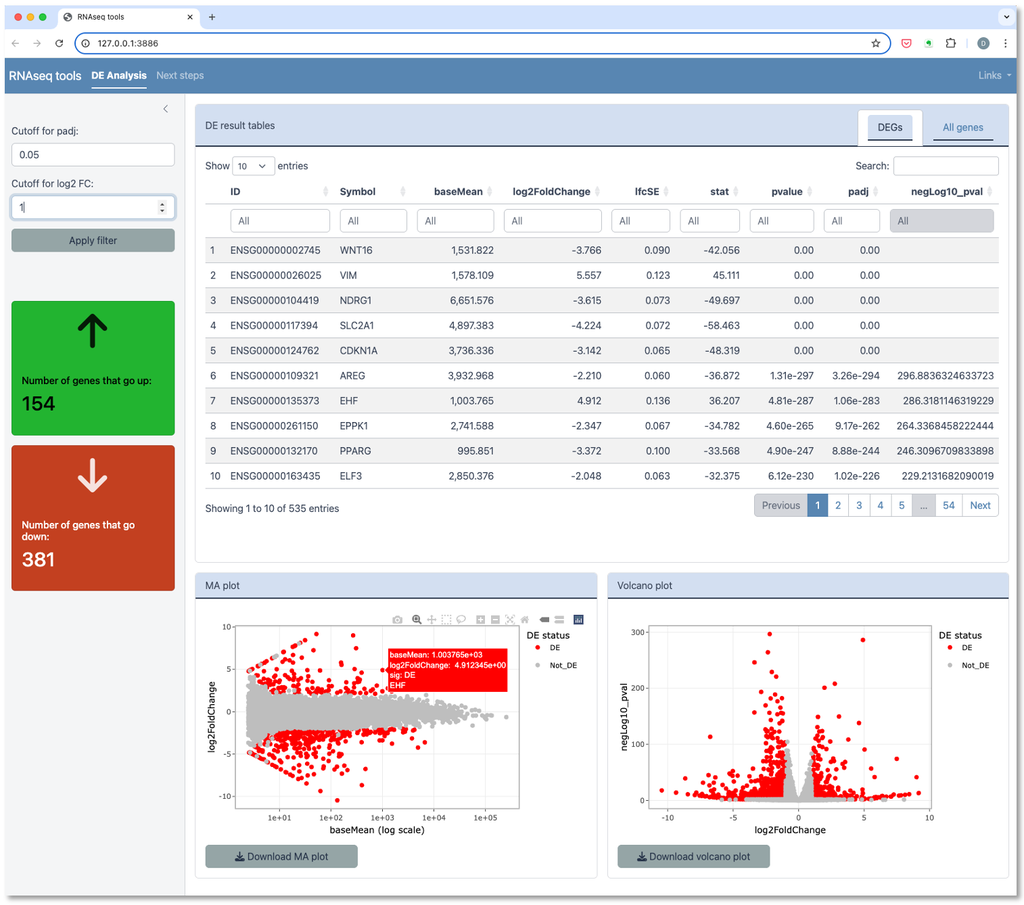

```r
shinyApp(ui = ui, server = server)
```

## Time for an exercise!

Exercises for Session 2 are here

## Answers to exercise.

Answers can be found here here

Rcode for answers can be found here here